# Lab 3: Exploring Happiness

Due: Thursday 10/03/2019 by 10 pm

Alex Beagle, Nathan Haas

10/02/2019

Owner’s Github: nahaas97 Partner’s Github: abeagle15 Repo Name: ds202_lab3

## Background

The General Social Survey (GSS) has been run by NORC every other year since 1972 to keep track of current opinions across the United States. We are working with an excerpt of the dataset that covers years 1972 to 2016. The variable names along with a brief description are as follows:

| Variable | Description |
| --- | --- |
| Year | Year for this respondent |
| Age | Age of respondent |
| Sex | Sex of respondent |
| happy | level of happiness |
| marital | Marital statue |
| degree | Education level |
| finrela | Opinion of income |
| health | status of health |
| polviews | view on politics |
| partyid | political identity |
| wtssall | weight of variables |

## Data Cleaning

Initial exploration revealed that some data processing was needed before we could proceed with further visualization. All missing values were encoded with ‘NA’ as follows:

```r
library(classdata)
happy <- readRDS("C:/Users/beagl/OneDrive/Documents/HAPPY.rds")
names(happy) = tolower(names(happy))

happy$polviews[happy$polviews %in% "IAP"] <- "NA"
happy$polviews[happy$polviews %in% "DK"] <- "NA"
happy$health[happy$health %in% "IAP"] <- "NA"
happy$health[happy$health %in% "DK"] <- "NA"
happy$finrela[happy$finrela %in% "IAP"] <- "NA"
happy$finrela[happy$finrela %in% "DK"] <- "NA"
```

Variables were also cast into the correct type in order to ease data visualization. This was done by:

```r
happy$age[happy$age == "89 OR OLDER"] <- "89"
happy$happy = as.character(happy$happy)
happy$year = as.numeric(happy$year)
happy$age = as.numeric(happy$age)
happy$sex = as.character(happy$sex)
happy$marital = as.character(happy$marital)
happy$degree = as.character(happy$degree)
happy$finrela = as.character(happy$finrela)
happy$health = as.character(happy$health)
happy$wtssall = as.numeric(happy$wtssall)
happy$partyid = as.character(happy$partyid)
happy$polviews = as.character(happy$polviews)
```

Factors were also organized into meaningful order as follows:

```r
library(tidyverse)
happyvsage = fct_reorder(happy$happy, happy$age, .fun=median, .desc = FALSE)
sexvsage = fct_reorder(happy$sex, happy$age, .fun=median, .desc = FALSE)
maritalvsage = fct_reorder(happy$marital, happy$age, .fun=median, .desc = FALSE)
degreevsage = fct_reorder(happy$degree, happy$age, .fun=median, .desc = FALSE)
finrelavsage = fct_reorder(happy$finrela, happy$age, .fun=median, .desc = FALSE)
healthvsage = fct_reorder(happy$health, happy$age, .fun=median, .desc = FALSE)
partyidvsage = fct_reorder(happy$partyid, happy$age, .fun=median, .desc = FALSE)
polviewsvsage = fct_reorder(happy$polviews, happy$age, .fun=median, .desc = FALSE)
```

## Data Exploration

Two variables of interest are `Year` and `Degree`. Their distributions are as follow:

[figure not shown]

```r
library(ggplot2)
ggplot(happy, aes(year, fill = sex)) + geom_histogram(binwidth=2) + labs(title="Histogram of Age by Sex", x="Year", y="Count")
```

The distribution for “year” is fairly uniform throughout the dataset, suggesting that a similar number of interviews were completed each year. The most interviews were conducted in 2006-2008, while the least number of interviews occurred around 1980. This ultimately suggests that the data set provides an accurate representation of multiple years of data.

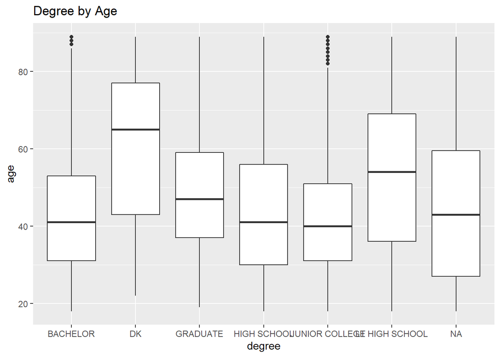

```r
ggplot(happy, aes(degree, age)) + geom_boxplot() + labs(title = "Degree by Age")
```

Next, we investigated the relationship between happiness and three variables in the data: health, age, and marital.

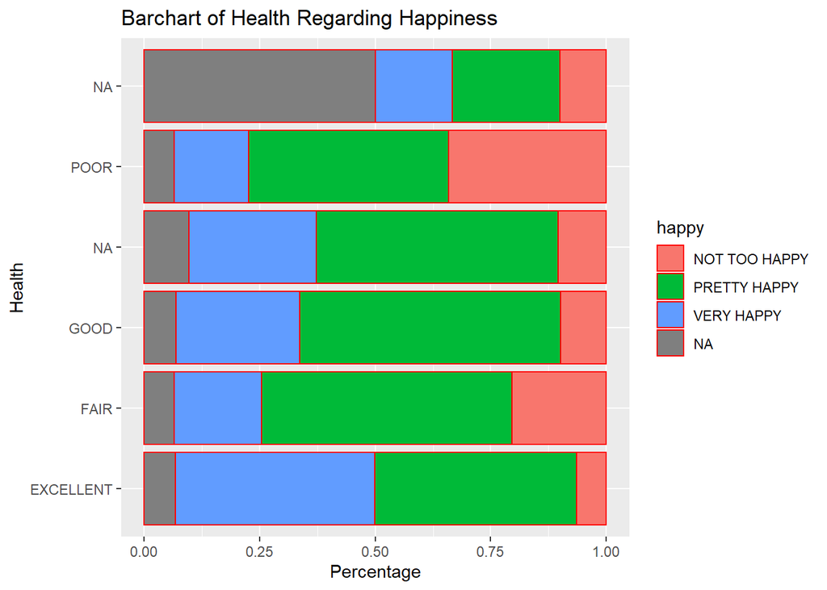

```r
ggplot(happy, aes(health, fill=happy)) + geom_bar(color="red", position="fill") + coord_flip() + labs(title = "Barchart of Health Regarding Happiness", y="Percentage", x="Health")
```

The distribution of health by happiness is as expected. The people with excellent health are generally the least likely to be not too happy, and this trend continues as people become less healthy. For example, people with poor health have the greatest proportion of people who are not happy; whereas, people with excellent health have the greatest proportion of people who are very happy.

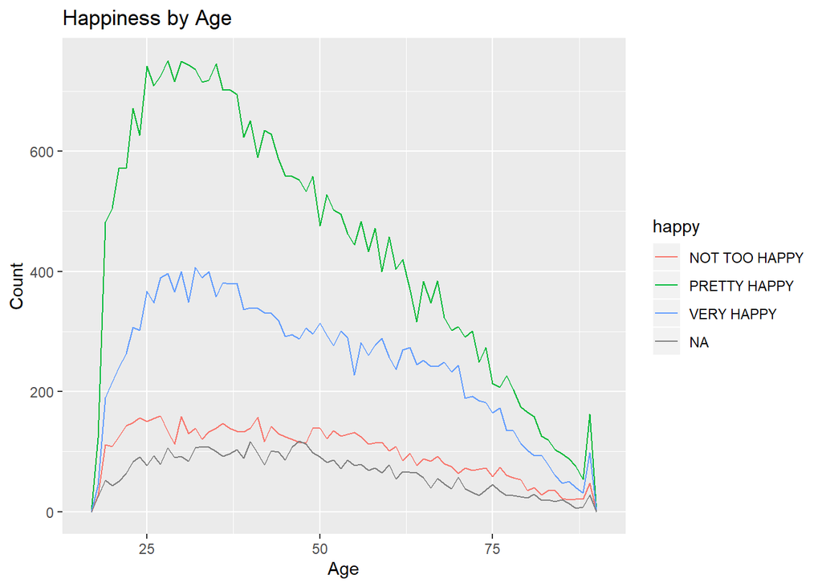

```r
ggplot(happy, aes(age, color=happy)) + geom_freqpoly(binwidth=1) + labs(title = "Happiness by Age", x="Age", y="Count")
```

We can see that the distribution is scewed to the right. This means that most of the entries come from younger particapants. As age goes on we can see that the gaps between each level of happiness grow closer together. This is due to the lower number of participants as age goes on. The jump at the end of the data is also due to the fact that multiple “older than 89” values have been changed to just “89”.

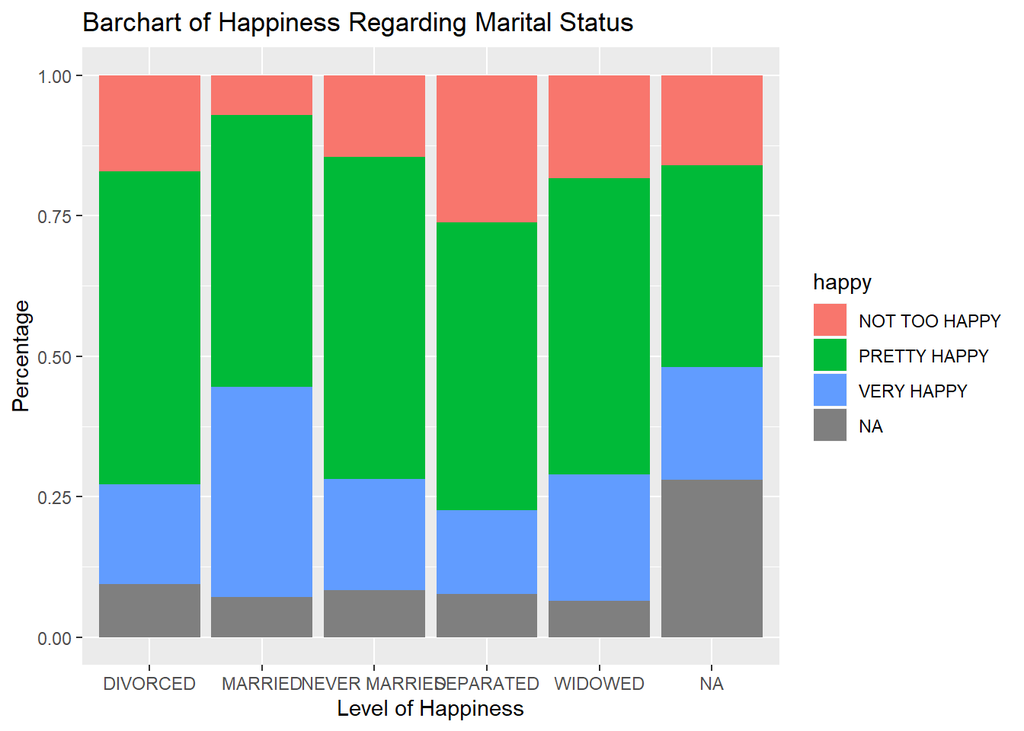

```r
ggplot(happy, aes(marital, fill=happy)) + geom_bar(position="fill") + labs(title = "Barchart of Happiness Regarding Marital Status", y="Percentage", x="Level of Happiness")
```